# Exploring Worldwide Trends in Women's Fertility, Per Capita Income, and Life Expectancy

### Q6: How does life expectancy relate to income over the past 100 years?

```python
income_life_exp_period_size = 20
income_life_exp_periods = [
    (str(int(current_year) - income_life_exp_period_size * 1), current_year),
    (str(int(current_year) - income_life_exp_period_size * 2), str(int(current_year) - income_life_exp_period_size * 1)),
    (str(int(current_year) - income_life_exp_period_size * 3), str(int(current_year) - income_life_exp_period_size * 2)),
    (str(int(current_year) - income_life_exp_period_size * 4), str(int(current_year) - income_life_exp_period_size * 3)),
    (str(int(current_year) - income_life_exp_period_size * 5), str(int(current_year) - income_life_exp_period_size * 4)),
]
income_life_exp_periods
```

```
[('2002', '2022'),
 ('1982', '2002'),
 ('1962', '1982'),
 ('1942', '1962'),
 ('1922', '1942')]
```

The code above creates 5 buckets with a size of 20 years each, starting from the current year and going back 100 years.

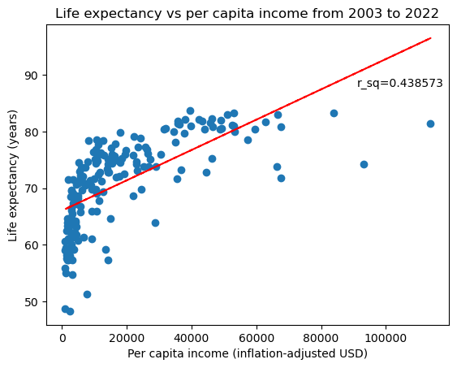

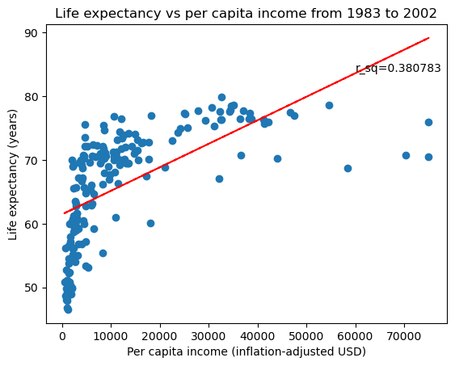

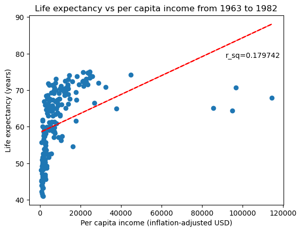

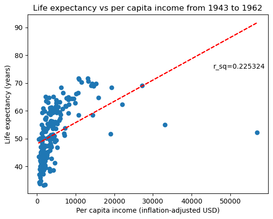

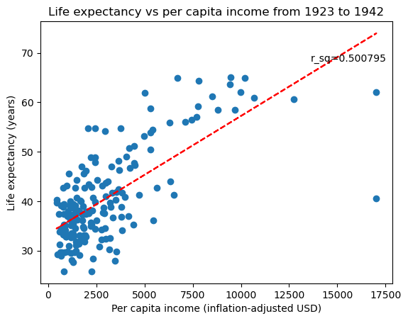

```python
for period_start, period_end in income_life_exp_periods:
    period_start = str(int(period_start) + 1)
    life_exp_cols = [str(num) for num in np.arange(int(period_start), int(period_end) + 1)]
    income_cols = [f'income_{str(num)}' for num in np.arange(int(period_start), int(period_end) + 1)]
    mean_period_life_exp_df = merged_income_life_exp_df.loc[:, life_exp_cols].mean(axis=1)
    mean_period_income_df = merged_income_life_exp_df.loc[:, income_cols].mean(axis=1)
    plt.scatter(mean_period_income_df, mean_period_life_exp_df);
    plt.title(f'Life expectancy vs per capita income from {period_start} to {period_end}')
    plt.xlabel('Per capita income (inflation-adjusted USD)')
    plt.ylabel('Life expectancy (years)')
    lin_reg_1_deg = np.polyfit(mean_period_income_df, mean_period_life_exp_df, 1)
    poly_1_deg = np.poly1d(lin_reg_1_deg)
    predicted_1_deg = poly_1_deg(mean_period_income_df)
    corr_matrix_1_deg = np.corrcoef(mean_period_life_exp_df, predicted_1_deg)
    coef_1_deg = corr_matrix_1_deg[0,1]**2
    plt.plot(mean_period_income_df, predicted_1_deg, 'r--')
    plt.text(mean_period_income_df.max() * 0.8, mean_period_life_exp_df.max() * 1.05, f'r_sq={coef_1_deg:.6f}')
    plt.show();
```

Interestingly, the charts also indicate that there are some notable outliers with income levels far above those of the other countries. In particular, the periods 1963-1982 and 2003-2022 each have a country with income levels above $100k per capita. That's very high, particularly from 1963 to 1982! What countries could those possibly be?

```python
period_cols_1963_1982 = ['country'] + [f'income_{str(num)}' for num in np.arange(1963, 1983)]
period_income_life_exp_df_1963_1982 = merged_income_life_exp_df.loc[:, period_cols_1963_1982]
period_income_life_exp_df_1963_1982[period_income_life_exp_df_1963_1982.iloc[:, 1:].mean(axis=1) > 100000]
```

|  | country | income_1963 | income_1964 | income_1965 | income_1966 | income_1967 | income_1968 | income_1969 | income_1970 | income_1971 | ... | income_1973 | income_1974 | income_1975 | income_1976 | income_1977 | income_1978 | income_1979 | income_1980 | income_1981 | income_1982 |
| --- | --- | --- | --- | --- | --- | --- | --- | --- | --- | --- | --- | --- | --- | --- | --- | --- | --- | --- | --- | --- | --- |
| 138 | qatar | 32700.0 | 40800.0 | 50900.0 | 63500.0 | 79100.0 | 98700.0 | 123000.0 | 153000.0 | 154000.0 | ... | 157000.0 | 153000.0 | 150000.0 | 153000.0 | 134000.0 | 137000.0 | 134000.0 | 121000.0 | 109000.0 | 90500.0 |

1 rows × 21 columns

For the 1963-1982 period, **Qatar** was the country! Some quick research reveals that this period [coincided with the discovery of oil reserves in Qatar](https://en.wikipedia.org/wiki/Economy_of_Qatar#:~:text=The%20exploration%20of%20oil%20and,downturn%20from%201982%20to%201989.), so perhaps that boost in national revenue being applied to a small population was responsible for such a high number.

```python
period_cols_2003_2022 = ['country'] + [f'income_{str(num)}' for num in np.arange(2003, 2023)]
period_income_life_exp_df_2003_2022 = merged_income_life_exp_df.loc[:, period_cols_2003_2022]
period_income_life_exp_df_2003_2022[period_income_life_exp_df_2003_2022.iloc[:, 1:].mean(axis=1) > 100000]
```

|  | country | income_2003 | income_2004 | income_2005 | income_2006 | income_2007 | income_2008 | income_2009 | income_2010 | income_2011 | ... | income_2013 | income_2014 | income_2015 | income_2016 | income_2017 | income_2018 | income_2019 | income_2020 | income_2021 | income_2022 |
| --- | --- | --- | --- | --- | --- | --- | --- | --- | --- | --- | --- | --- | --- | --- | --- | --- | --- | --- | --- | --- | --- |
| 101 | luxembourg | 105000.0 | 108000.0 | 109000.0 | 113000.0 | 121000.0 | 118000.0 | 112000.0 | 114000.0 | 113000.0 | ... | 113000.0 | 113000.0 | 113000.0 | 116000.0 | 115000.0 | 115000.0 | 117000.0 | 112000.0 | 118000.0 | 119000.0 |

1 rows × 21 columns

For the 2003-2022 period, **Luxembourg** was the country! Some quick research reveals that Luxembourg has a large share of workers who work across borders and therefore are not considered residents even though their income contributes to the country's GDP (read [here](https://ec.europa.eu/eurostat/web/products-eurostat-news/-/ddn-20211215-1#:~:text=For%20more%20information%3A,to%20calculate%20GDP%20per%20capita.)). In other words, the per capita income calculation unintentionally assigns the income of those cross-border workers to the remaining citizens who're full-time residents of the country.

## Conclusions

This exploration has revealed some interesting trends in the levels of fertility, income, and life expectancy in different parts of the world. In summary:

- fertility rates are still very high (>= 5 babies per woman) in some parts of the world, whereas in other parts of the world fertility rates are well below the threshold needed to maintain population levels (~2.1 babies per woman).
- the majority of countries have fertility rates that are closer to the lower end of the worldwide range than to the higher end.
- more countries have broken into the upper income bracket in the past 200 years, although the gap between richest and poorest countries widened during that same period.
- the distribution of income in the world has skewed in favor of the "West" (North America, Europe, Australia, and New Zealand) for the last 200 years, whereas Sub-Saharan Africa and Melanesia have remained among the poorest regions over the same period of time.
- life expectancy was relatively flat between 1823 and 1922, then began to rise quite dramatically afterwards. More so, an increasing portion of countries appear to have benefitted from the gains in life expectancy.
- life expectancy is currently highest in the "West" and lowest in Sub-Saharan Africa, Melanesia, Micronesia.
- life expectancy appears to have only a partial correlation with per capita income. Increases in income level from a low starting point appear correlated to higher life expectancy, but only up to a point.

It must be restated that this exploration was not intended to imply causation between any of the examined metrics. Any trends shown here are at best correlation rather than causation.

## Resources

- Pandas documentation: https://pandas.pydata.org/pandas-docs/stable/reference/index.html
- Numpy documentation: https://numpy.org/doc/stable/reference/index.html
- Eurostat: https://ec.europa.eu/eurostat/web/products-eurostat-news/-/ddn-20211215-1#:~:text=For%20more%20information%3A,to%20calculate%20GDP%20per%20capita.
- Wikipedia: https://en.wikipedia.org/wiki/Economy_of_Qatar#:~:text=The%20exploration%20of%20oil%20and,downturn%20from%201982%20to%201989.
- Gapminder World Dataset: https://www.gapminder.org/data/